# Burden

Use a newly calculated set of motif change scores to define motif SNVs, but only focusing on motifs that more relevant Here motifs are defined as relevant if they are 1) in top 50% brain expressed genes, and 2) are enriched in at least one gain-enriched brain module Partition enhancers based on distance to TSS based on Yanyu’s pipeline. Basically, her pipeline takes intersections between enhancers and distance ranges, and remove bases of enhancers that are not overlap.

non ASD genes are the bottom 20% not plotting mutation is 5’UTR or 3’UTR added one row for showing the union of enhancers and promoters

```r
getwd()
```

```
## [1] "/media/yuwen/F/ASD/analysis"
```

```r
knitr::opts_chunk$set(warning=FALSE, message=FALSE)
```

### read in coding tada data

[output not shown]

Whole genome

Noonan enhancers

DHS

Brain roadmap

Fantom fetal brain

get the burden of mutations within 20kb-100kb of NP genes Noonan Brain union and Gerp > 2

```r
temp = generate_mut_enhancer_pair_for_burden_analysis("0703_data_for_analysis.bed","../other_annotation/epigenomic_annotation/Noonan_brain_union.yanyu_pipeline_enhancers.20000_to_100000.bp_within_TSS.bed")
burden_with_gerp(burden_with_geneset(temp, relaxed_ASD)$mut, mutation$gerp, 2, as.numeric(quantile(mutation$gerp[,8], c(1))))$burden
```

```
## [1] 20.0000000 31.0000000  0.6343277
```

get the burden of mutations within 20kb-100kb of NP genes Noonan Brain union and CADD > 10

```r
temp = generate_mut_enhancer_pair_for_burden_analysis("0703_data_for_analysis.bed","../other_annotation/epigenomic_annotation/Noonan_brain_union.yanyu_pipeline_enhancers.20000_to_100000.bp_within_TSS.bed")
burden_with_CADD(burden_with_geneset(temp,relaxed_ASD)$mut, CADD_score_with_index, 10, as.numeric(quantile(mutation$CADD_score[,1], c(1))))$burden
```

```
## [1] 16.0000000 17.0000000  0.9253722
```

get the burden of mutations within 20kb-100kb of NP genes ENCODE DHS and Gerp > 2

```r
temp = generate_mut_enhancer_pair_for_burden_analysis("0703_data_for_analysis.bed","../other_annotation/epigenomic_annotation/Encode_DHS_union.yanyu_pipeline_enhancers.20000_to_100000.bp_within_TSS.bed")
burden_with_gerp(burden_with_geneset(temp, relaxed_ASD)$mut, mutation$gerp, 2, as.numeric(quantile(mutation$gerp[,8], c(1))))$burden
```

```
## [1]  7.000000 21.000000  0.327736
```

get the burden of mutations within 20kb-100kb of NP genes ENCODE DHS and CADD > 10

```r
temp = generate_mut_enhancer_pair_for_burden_analysis("0703_data_for_analysis.bed","../other_annotation/epigenomic_annotation/Encode_DHS_union.yanyu_pipeline_enhancers.20000_to_100000.bp_within_TSS.bed")
burden_with_CADD(burden_with_geneset(temp,relaxed_ASD)$mut, CADD_score_with_index, 10, as.numeric(quantile(mutation$CADD_score[,1], c(1))))$burden
```

```
## [1]  6.0000000 15.0000000  0.3932832
```

get the burden of mutations within 20kb-500kb of NP genes Noonan Brain union and Gerp > 2

```r
temp = generate_mut_enhancer_pair_for_burden_analysis("0703_data_for_analysis.bed","../other_annotation/epigenomic_annotation/Noonan_brain_union.yanyu_pipeline_enhancers.20000_to_500000.bp_within_TSS.bed")
burden_with_gerp(burden_with_geneset(temp, relaxed_ASD)$mut, mutation$gerp, 2, as.numeric(quantile(mutation$gerp[,8], c(1))))$burden
```

```
## [1] 48.0000000 55.0000000  0.8580724
```

get the burden of mutations within 20kb-500kb of NP genes Noonan Brain union and CADD > 10

```r
temp = generate_mut_enhancer_pair_for_burden_analysis("0703_data_for_analysis.bed","../other_annotation/epigenomic_annotation/Noonan_brain_union.yanyu_pipeline_enhancers.20000_to_500000.bp_within_TSS.bed")
burden_with_CADD(burden_with_geneset(temp,relaxed_ASD)$mut, CADD_score_with_index, 10, as.numeric(quantile(mutation$CADD_score[,1], c(1))))$burden
```

```
## [1] 34.0000000 37.0000000  0.9034884
```

get the burden of mutations within 20kb-500kb of NP genes ENCODE DHS and Gerp > 2

```r
temp = generate_mut_enhancer_pair_for_burden_analysis("0703_data_for_analysis.bed","../other_annotation/epigenomic_annotation/Encode_DHS_union.yanyu_pipeline_enhancers.20000_to_500000.bp_within_TSS.bed")
burden_with_gerp(burden_with_geneset(temp, relaxed_ASD)$mut, mutation$gerp, 2, as.numeric(quantile(mutation$gerp[,8], c(1))))$burden
```

```
## [1] 18.0000000 30.0000000  0.5899248
```

get the burden of mutations within 20kb-500kb of NP genes ENCODE DHS and CADD > 10

```r
temp = generate_mut_enhancer_pair_for_burden_analysis("0703_data_for_analysis.bed","../other_annotation/epigenomic_annotation/Encode_DHS_union.yanyu_pipeline_enhancers.20000_to_500000.bp_within_TSS.bed")
burden_with_CADD(burden_with_geneset(temp,relaxed_ASD)$mut, CADD_score_with_index, 10, as.numeric(quantile(mutation$CADD_score[,1], c(1))))$burden
```

```
## [1] 18.0000000 21.0000000  0.8427497
```

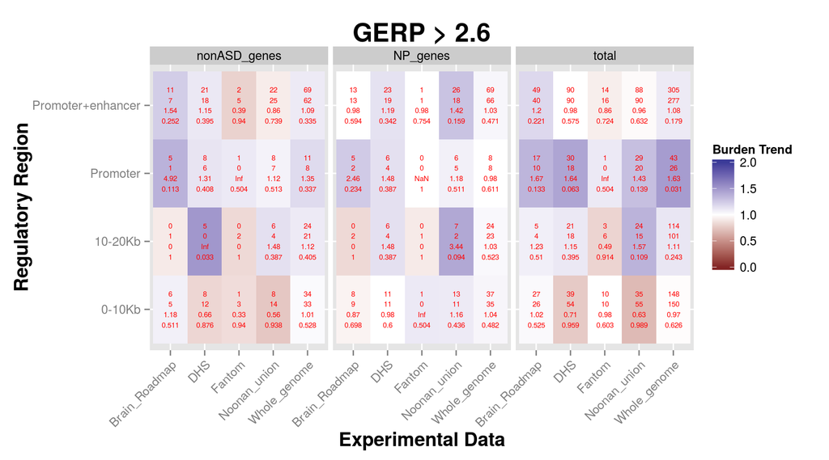

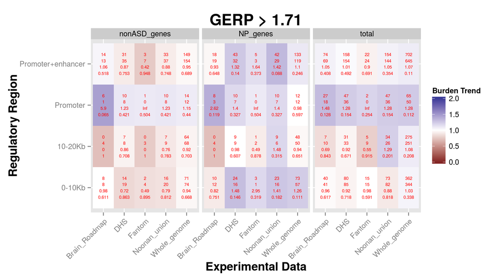

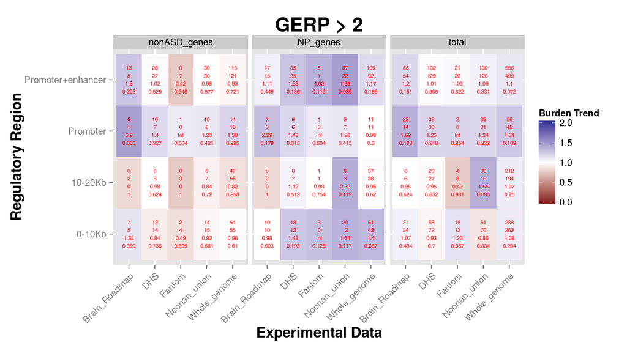

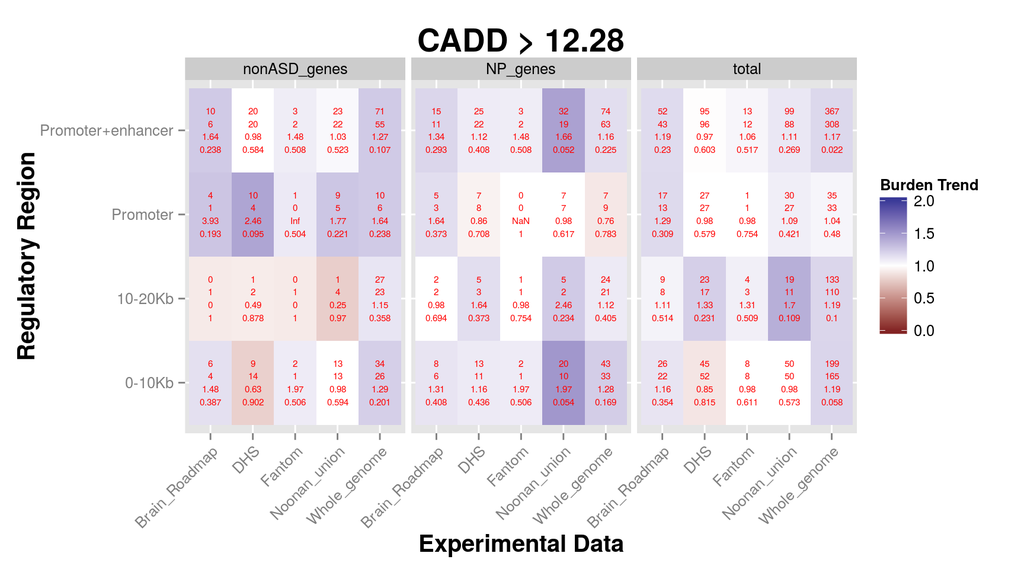

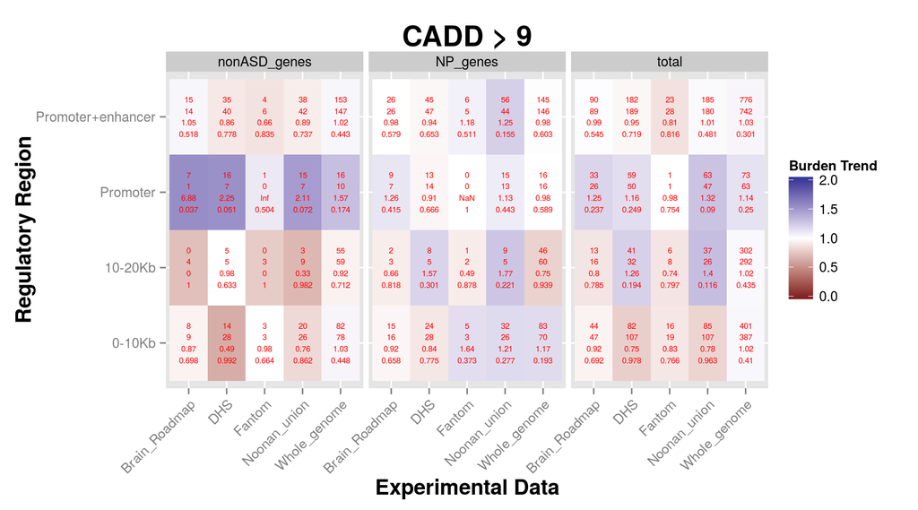

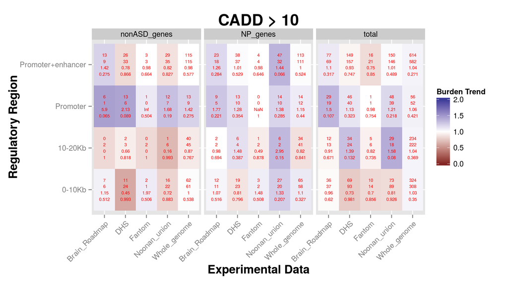

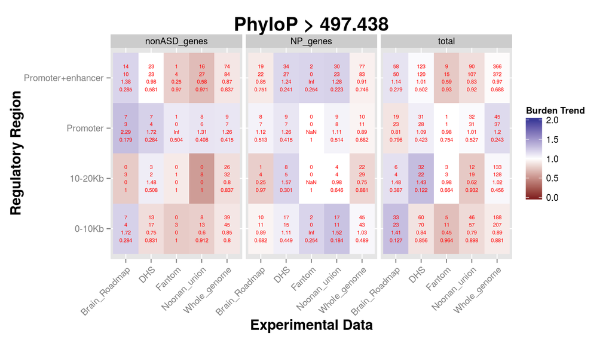

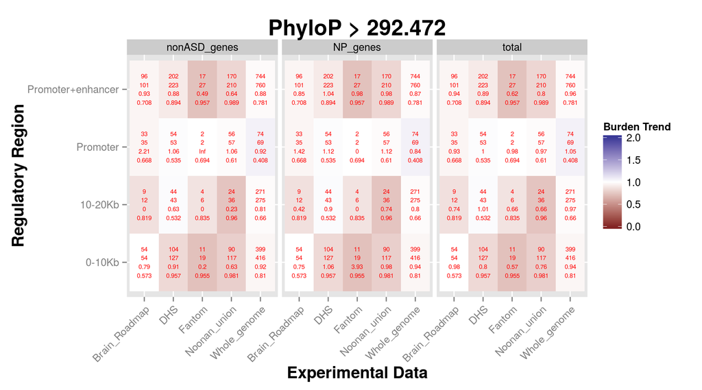

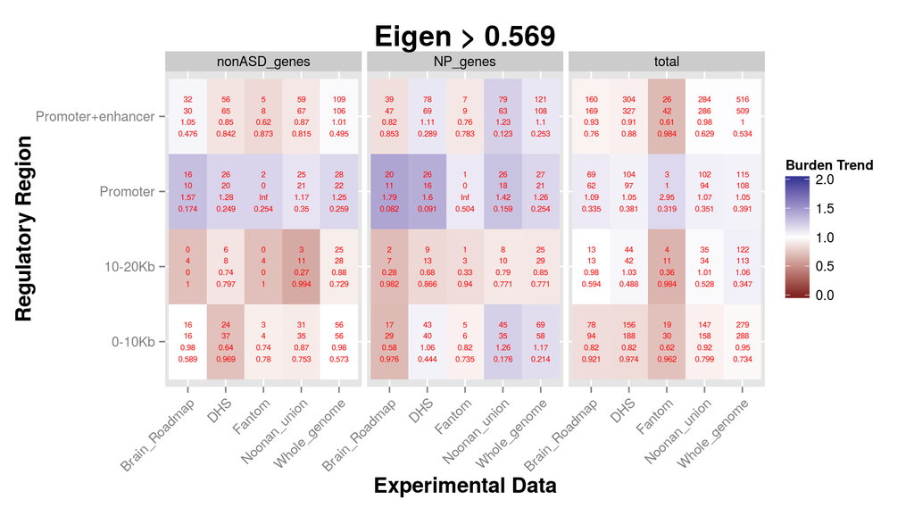

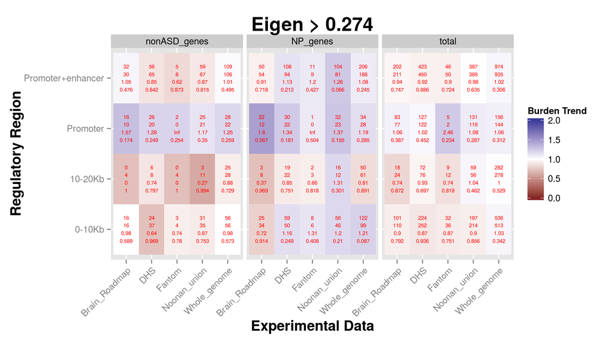

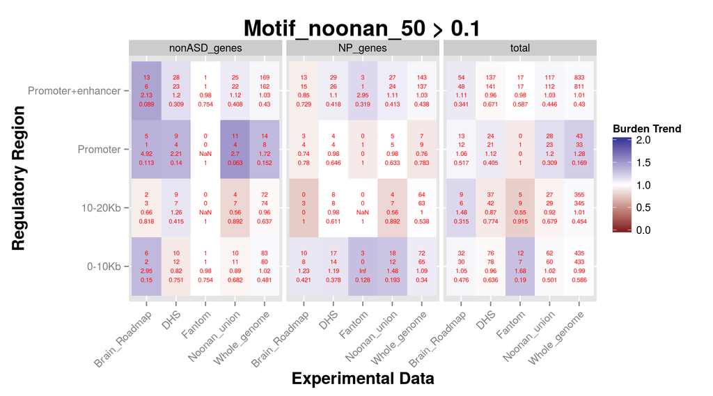

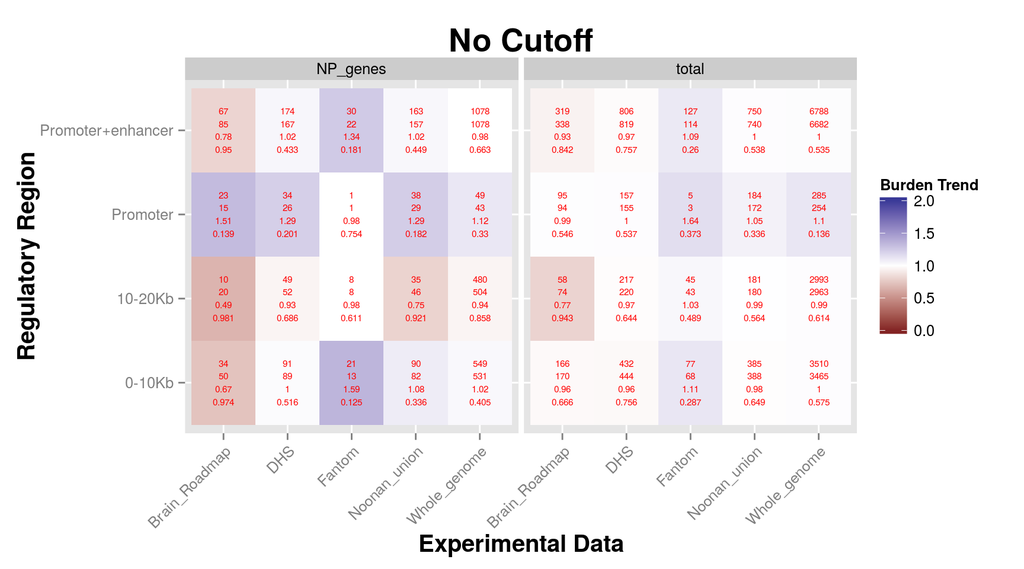

```r
plot_summary = plot_summary[!is.na(plot_summary$gene_list),]
```